# 19BCE1180_GGPLOT

##NAME: AVIREDDY NVSRK ROHAN ##REG.NO: 19BCE1180

Ex-6 Visualization using grammar of graphics

```r
library(ggplot2)
library(dplyr)
```

Use the newsurvey data obtained by cleaning ‘na’ values in survey data of MASS package and ggplot2 package to do the following:

```r
library("MASS")
data("survey")
survey_data=survey
str(survey_data)
```

```
## 'data.frame':    237 obs. of  12 variables:
##  $ Sex   : Factor w/ 2 levels "Female","Male": 1 2 2 2 2 1 2 1 2 2 ...
##  $ Wr.Hnd: num  18.5 19.5 18 18.8 20 18 17.7 17 20 18.5 ...
##  $ NW.Hnd: num  18 20.5 13.3 18.9 20 17.7 17.7 17.3 19.5 18.5 ...
##  $ W.Hnd : Factor w/ 2 levels "Left","Right": 2 1 2 2 2 2 2 2 2 2 ...
##  $ Fold  : Factor w/ 3 levels "L on R","Neither",..: 3 3 1 3 2 1 1 3 3 3 ...
##  $ Pulse : int  92 104 87 NA 35 64 83 74 72 90 ...
##  $ Clap  : Factor w/ 3 levels "Left","Neither",..: 1 1 2 2 3 3 3 3 3 3 ...
##  $ Exer  : Factor w/ 3 levels "Freq","None",..: 3 2 2 2 3 3 1 1 3 3 ...
##  $ Smoke : Factor w/ 4 levels "Heavy","Never",..: 2 4 3 2 2 2 2 2 2 2 ...
##  $ Height: num  173 178 NA 160 165 ...
##  $ M.I   : Factor w/ 2 levels "Imperial","Metric": 2 1 NA 2 2 1 1 2 2 2 ...
##  $ Age   : num  18.2 17.6 16.9 20.3 23.7 ...
```

```r
newsurvey <- na.omit(survey_data)
head(newsurvey)
```

```
##      Sex Wr.Hnd NW.Hnd W.Hnd    Fold Pulse  Clap Exer Smoke Height      M.I
## 1 Female   18.5   18.0 Right  R on L    92  Left Some Never 173.00   Metric
## 2   Male   19.5   20.5  Left  R on L   104  Left None Regul 177.80 Imperial
## 5   Male   20.0   20.0 Right Neither    35 Right Some Never 165.00   Metric
## 6 Female   18.0   17.7 Right  L on R    64 Right Some Never 172.72 Imperial
## 7   Male   17.7   17.7 Right  L on R    83 Right Freq Never 182.88 Imperial
## 8 Female   17.0   17.3 Right  R on L    74 Right Freq Never 157.00   Metric
##      Age
## 1 18.250
## 2 17.583
## 5 23.667
## 6 21.000
## 7 18.833
## 8 35.833
```

1. Plot a bar graph for the number of male and female participants in the survey. Provide the title as “Male and Female participants” and specify the colours for the bars.

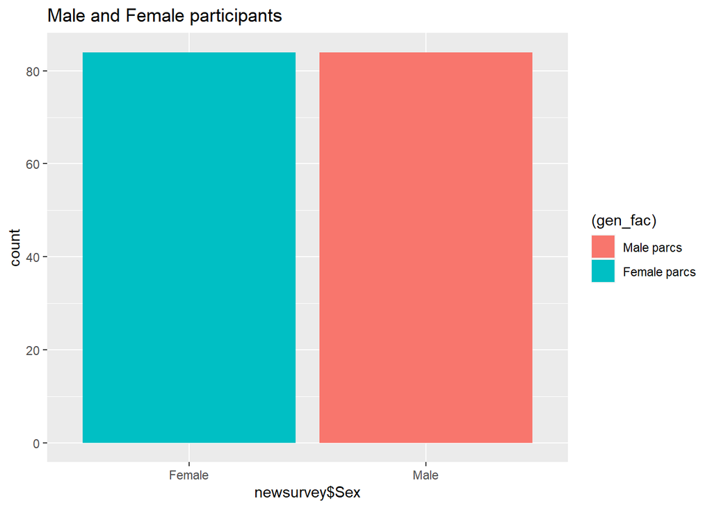

```r
gen_fac=factor(newsurvey$Sex,levels=c("Male","Female"),labels = c("Male parcs","Female parcs"))
ggplot(newsurvey,aes(x=newsurvey$Sex,fill=(gen_fac)))+geom_bar()+ggtitle("Male and Female participants")
```

2. Plot a bar graph for the number of left handers and right handers in the survey. Provide the title as “Left Handers and Right Handers” and specify the colours for the bars.

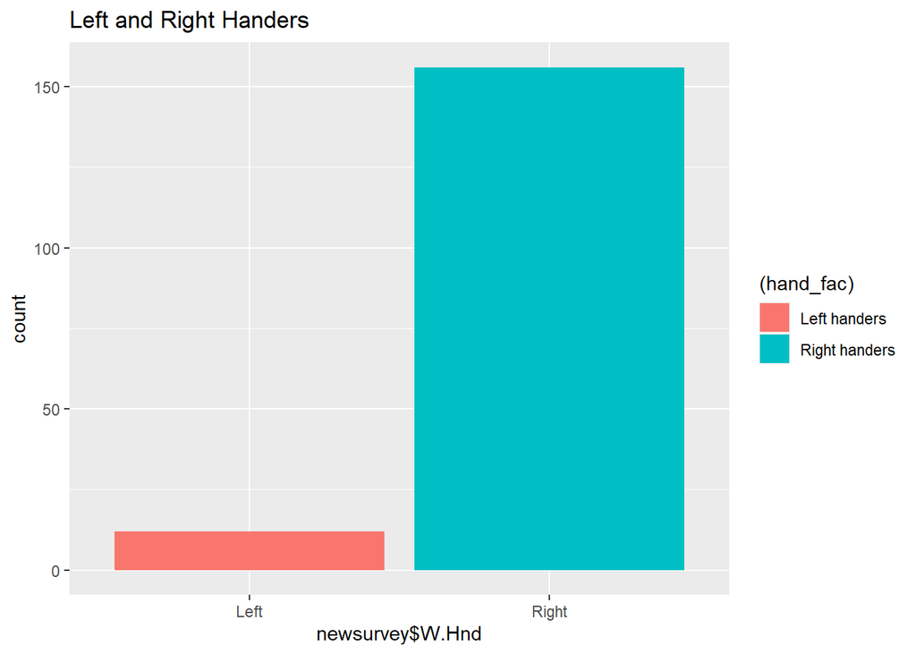

```r
hand_fac=factor(newsurvey$W.Hnd,levels=c("Left","Right"),labels = c("Left handers","Right handers"))
ggplot(newsurvey,aes(x=newsurvey$W.Hnd,fill=(hand_fac)))+geom_bar()+ggtitle("Left and Right Handers")
```

3. Plot the distribution between male right handers and female right handers using bar chart. Provide the title as “Female Right Handers and Male Right Handers” and specify the colours for the bars.

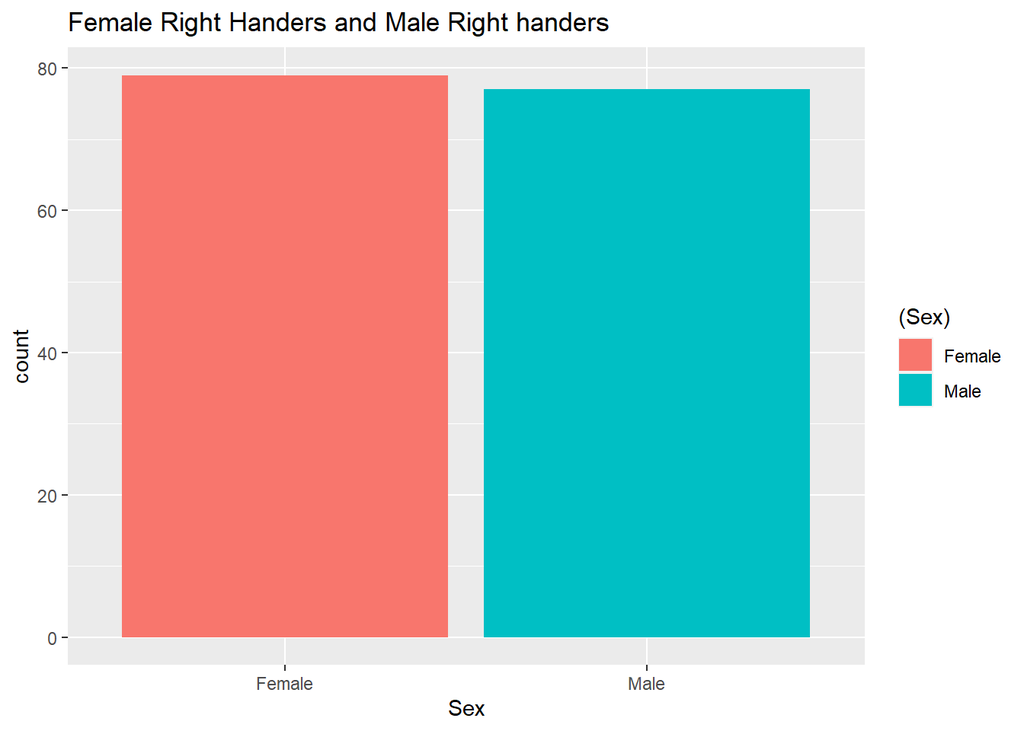

```r
temp <- newsurvey%>%
        filter(W.Hnd=="Right")
ggplot(temp,aes(x=Sex,fill=(Sex)))+geom_bar()+ggtitle("Female Right Handers and Male Right handers")
```

4. Draw the distribution of smoking habits of female left handers based on age using pie chart.

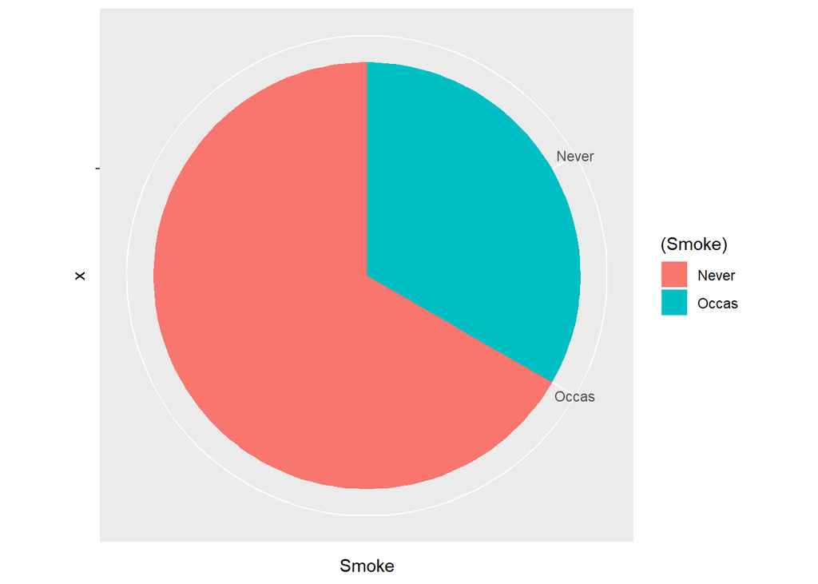

```r
library(dplyr)

temp <- newsurvey %>%
          filter(Sex=="Female",W.Hnd=="Left")

smoke_fac=factor(temp$Smoke,levels =c("Never","Occas"))
ggplot(temp,aes(x="",y=Smoke,fill=(Smoke)))+geom_bar(width = 1,stat='identity')+coord_polar("y",start = 0)
```

5. Draw the histogram of age distribution with the title as ‘Age distribution’ and xlabel as ‘Age range’ and ylabel as ‘frequency’.

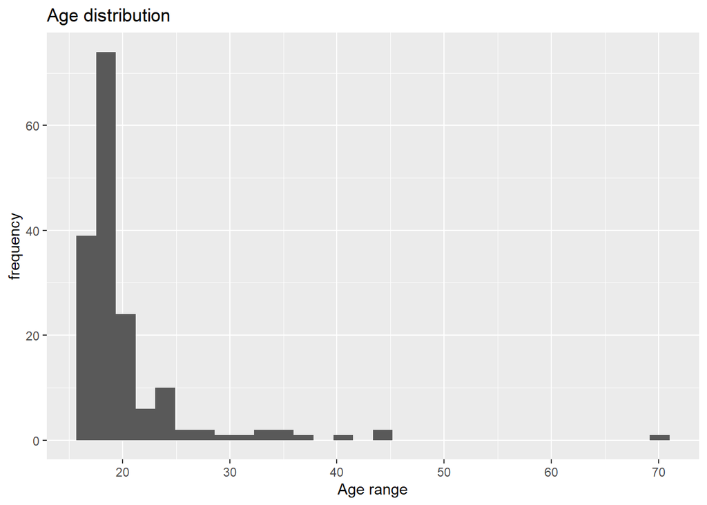

```r
ggplot(newsurvey,aes(x=Age))+geom_histogram()+labs(title ="Age distribution",x="Age range",y="frequency")
```

6. Reveal the relationship between the age and writing hand span using scatter plot.

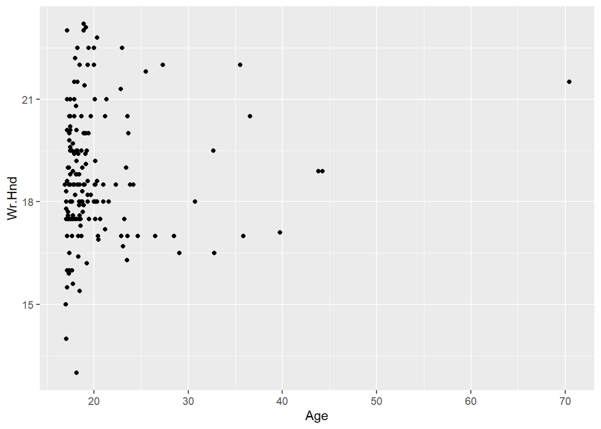

```r
ggplot(newsurvey,aes(x=Age,y=Wr.Hnd))+geom_point()
```

7. Plot the distribution of writing hand span vs. pulse rate of right handers. Provide colour based on gender and vary the size of the point based on height of the student.

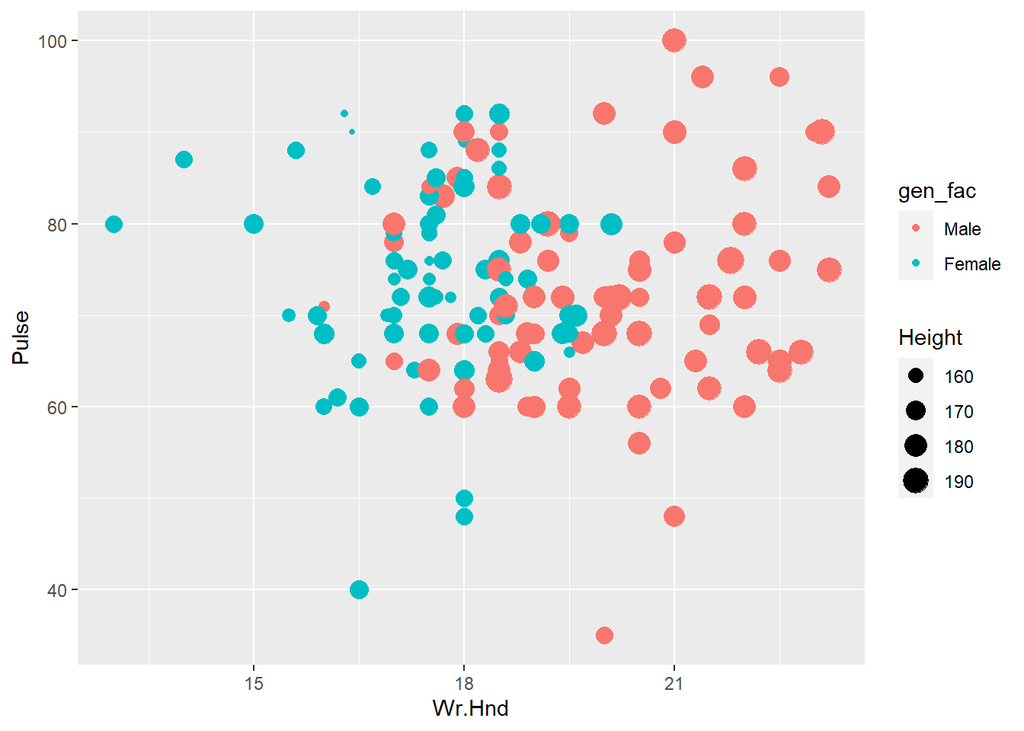

```r
temp=newsurvey%>%
      filter(W.Hnd=="Right")
gen_fac=factor(temp$Sex,levels=c("Male","Female"))
ggplot(temp,aes(x=Wr.Hnd,y=Pulse,size=Height,color=gen_fac))+geom_point()
```

8. Plot the distribution of height of the students with filled colour based on gender with facet based on left and write handers.

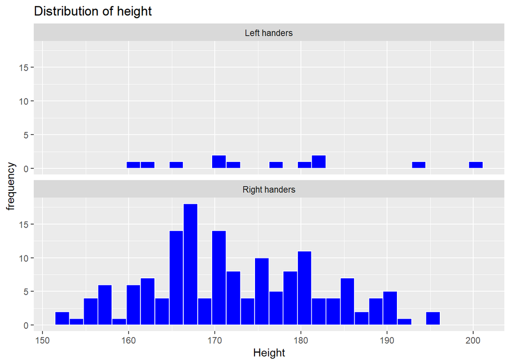

```r
ggplot(newsurvey,aes(x=Height))+geom_histogram(color="white",fill="blue")+labs(title = "Distribution of height",y='frequency')+facet_wrap(hand_fac,ncol=1)
```

##INFERENCE: THERE ARE MORE RIGHT HANDERS WITH HEIGHT FROM 160-170CM COMPARED TO LEFTHANDERS IN THE SAME RANGE

9. Plot the trend of span of writing hand vs. non-writing hand coloured and grouped based on left and right handers with facet label based on exercise.

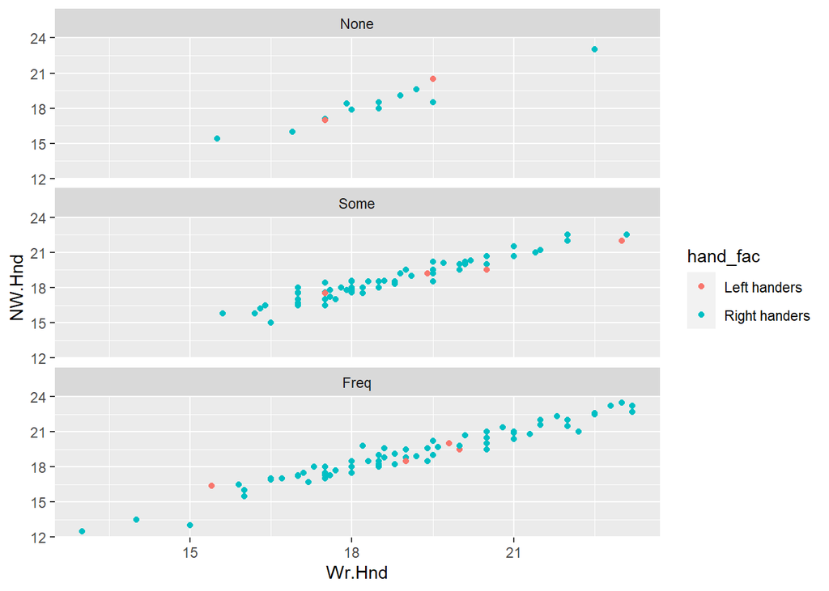

```r
ex_fac=factor(newsurvey$Exer,levels =c("None","Some","Freq"))
ggplot(newsurvey,aes(x=Wr.Hnd,y=NW.Hnd,color=hand_fac))+geom_point()+facet_wrap(ex_fac,ncol=1)
```

##RIGHT HANDERS ARE MORE FREQUENT WITH THEIR EXERCISE ROUTINE COMPARED TO LEFT HANDERS

10. Plot the distribution of age of students based on categories under clap with facet wrap based on gender.

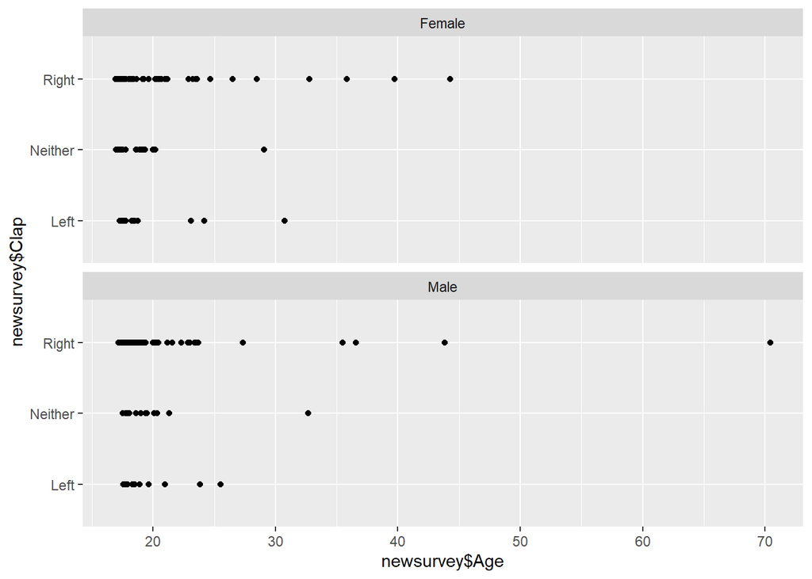

```r
ggplot(newsurvey,aes(y=newsurvey$Clap,x=newsurvey$Age))+geom_point()+facet_wrap(newsurvey$Sex,ncol=1)
```

11. Plot the box plot of writing hand span with respect to exercise category of students.

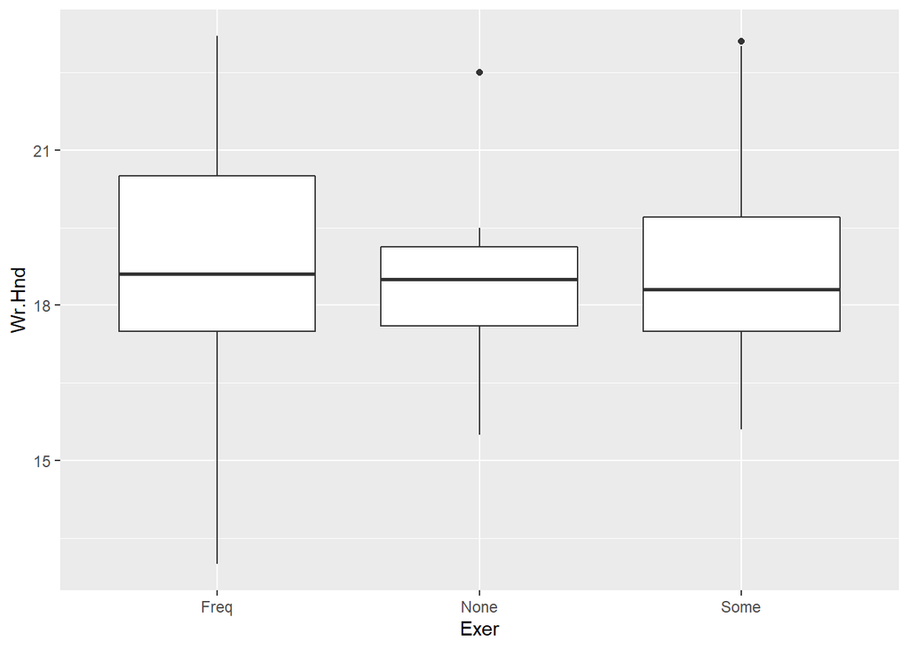

```r
ggplot(newsurvey, aes(x=Exer,y=Wr.Hnd))+geom_boxplot()
```

##INFERENCE: THE MEDIAN WR HAND SPAN FOR PEOPLE DOING SOME EXERCISE IS LESS THAN COMPARED TO THE FREQUENT AND NONE